# PA 9.1 Decision Boundaries

Author

Antonio Gutierrez

## The Data

At this link, you will find a dataset containing information about heart disease patients: https://www.dropbox.com/scl/fi/0vrpdnq5asmeulc4gd50y/ha_1.csv?rlkey=ciisalceotl77ffqhqe3kujzv&dl=1

A description of the original dataset can be found here: https://archive.ics.uci.edu/dataset/45/heart+disease (However, this dataset has been cleaned and reduced, and the people have been given fictious names.)

```python
import pandas as pd
import numpy as np
from sklearn.pipeline import Pipeline
from sklearn.neighbors import KNeighborsRegressor, KNeighborsClassifier
from sklearn.tree import DecisionTreeRegressor
from sklearn.linear_model import LogisticRegression, LinearRegression
from sklearn.neighbors import NearestNeighbors
from sklearn.metrics import mean_squared_error, r2_score, accuracy_score, confusion_matrix, classification_report
from plotnine import *
from sklearn.preprocessing import OneHotEncoder, label_binarize, StandardScaler
from sklearn.compose import ColumnTransformer
from sklearn.model_selection import train_test_split
from sklearn.discriminant_analysis import LinearDiscriminantAnalysis
from sklearn.svm import SVC
```

```python
data = pd.read_csv("/content/ha_1.csv")
data.head()
```

|  | Name | age | sex | cp | trtbps | chol | restecg | thalach | diagnosis |
| --- | --- | --- | --- | --- | --- | --- | --- | --- | --- |
| 0 | Magnolia Cassin | 60 | 1 | 1 | 117 | 230 | 1 | 160 | No Disease |
| 1 | Dr. Cathern Heathcote | 60 | 0 | 3 | 102 | 318 | 1 | 160 | Disease |
| 2 | Miles Wolf | 62 | 0 | 3 | 130 | 263 | 1 | 97 | No Disease |
| 3 | Mikaila Block | 43 | 1 | 1 | 115 | 303 | 1 | 181 | Disease |
| 4 | Mrs. Jacquline Marquardt | 66 | 1 | 1 | 120 | 302 | 0 | 151 | Disease |

```python
knn = KNeighborsRegressor()
dt = DecisionTreeRegressor()
knn = KNeighborsRegressor()
dt = DecisionTreeRegressor()
lr = LinearRegression()
enc = OneHotEncoder()
lg = LogisticRegression()
lda = LinearDiscriminantAnalysis()
```

```python
ct = ColumnTransformer(
    [
    ('dummify_sex', enc, ['sex']),],
    remainder = 'passthrough'
)
```

```python
data['diagnosis'] = data['diagnosis'].map({'Disease': 0, 'No Disease': 1})
data
```

|  | Name | age | sex | cp | trtbps | chol | restecg | thalach | diagnosis |
| --- | --- | --- | --- | --- | --- | --- | --- | --- | --- |
| 0 | Magnolia Cassin | 60 | 1 | 1 | 117 | 230 | 1 | 160 | 1 |
| 1 | Dr. Cathern Heathcote | 60 | 0 | 3 | 102 | 318 | 1 | 160 | 0 |
| 2 | Miles Wolf | 62 | 0 | 3 | 130 | 263 | 1 | 97 | 1 |
| 3 | Mikaila Block | 43 | 1 | 1 | 115 | 303 | 1 | 181 | 0 |
| 4 | Mrs. Jacquline Marquardt | 66 | 1 | 1 | 120 | 302 | 0 | 151 | 0 |
| ... | ... | ... | ... | ... | ... | ... | ... | ... | ... |
| 199 | Bridgett Franecki | 55 | 0 | 1 | 128 | 205 | 2 | 130 | 1 |
| 200 | Mr. Foster Zieme | 51 | 1 | 3 | 94 | 227 | 1 | 154 | 0 |
| 201 | Lashanda Hagenes | 42 | 1 | 2 | 120 | 295 | 1 | 162 | 0 |
| 202 | Levern Trantow III | 35 | 0 | 1 | 138 | 183 | 1 | 182 | 0 |
| 203 | Mahalia DuBuque DVM | 34 | 1 | 4 | 118 | 182 | 0 | 174 | 0 |

204 rows × 9 columns

## 1. Logistic Regression

Fit a Logistic Regression using only `age` and `chol` (cholesterol) as predictors.

For a 55 year old, how high would their cholesterol need to be for the doctors to predict heart disease is present?

How high for the doctors to estimate a 90% chance that heart disease is present?

```python
X = data[['age', 'chol']]
y = data['diagnosis']
```

```python
my_pipeline = Pipeline(
    [('lgr', LogisticRegression())]
)
```

```python
logpredict = my_pipeline.fit(X, y)
```

```python
ypreds = logpredict.predict(X)
ypreds
```

```
array([0, 1, 1, 0, 1, 0, 1, 1, 0, 0, 0, 0, 0, 0, 1, 1, 1, 0, 0, 1, 0, 1,
       0, 0, 1, 0, 0, 1, 0, 0, 1, 0, 1, 0, 0, 0, 0, 0, 0, 1, 1, 0, 0, 1,
       0, 0, 0, 1, 1, 1, 0, 1, 1, 1, 0, 0, 1, 0, 1, 0, 0, 0, 0, 0, 0, 1,
       0, 0, 1, 0, 0, 0, 0, 0, 0, 1, 1, 1, 0, 1, 0, 0, 0, 0, 0, 1, 0, 0,
       0, 0, 1, 0, 0, 0, 0, 0, 0, 0, 0, 0, 1, 0, 0, 0, 0, 0, 1, 1, 0, 0,
       0, 0, 0, 1, 1, 0, 0, 1, 0, 0, 0, 1, 0, 0, 0, 0, 1, 0, 0, 0, 0, 0,
       0, 0, 0, 0, 0, 1, 0, 0, 1, 1, 0, 0, 0, 0, 1, 0, 0, 0, 0, 0, 1, 0,
       1, 1, 0, 1, 0, 0, 1, 0, 0, 0, 1, 0, 0, 0, 1, 0, 1, 0, 1, 0, 1, 1,
       0, 1, 0, 0, 0, 1, 1, 0, 0, 0, 0, 0, 0, 1, 0, 0, 0, 0, 1, 0, 0, 0,
       0, 0, 0, 0, 0, 0])
```

```python
logpredict.named_steps['lgr'].coef_
```

```
array([[0.04686331, 0.00180124]])
```

```python
logpredict.named_steps['lgr'].intercept_
```

```
array([-3.24011226])
```

```python
accuracy = accuracy_score(y, ypreds)
accuracy
```

```
0.5784313725490197
```

## 2. Linear Discriminant Analysis

Fit an LDA model using only `age` and `chol` (cholesterol) as predictors.

For a 55 year old, how high would their cholesterol need to be for the doctors to predict heart disease is present?

```python
my_pipeline = Pipeline(
    [('lda', LinearDiscriminantAnalysis())]
)
```

```python
ldapredict = my_pipeline.fit(X, y)
```

```python
ypreds = ldapredict.predict(X)
ypreds
```

```
array([0, 1, 1, 0, 1, 0, 1, 1, 0, 0, 0, 0, 0, 0, 1, 1, 1, 0, 0, 1, 0, 1,
       0, 0, 1, 0, 0, 1, 0, 0, 1, 0, 1, 0, 0, 0, 0, 0, 0, 1, 1, 0, 0, 1,
       0, 0, 0, 1, 1, 1, 0, 1, 1, 1, 0, 0, 1, 0, 1, 0, 0, 0, 0, 0, 0, 1,
       0, 0, 1, 0, 0, 0, 0, 0, 0, 1, 1, 1, 0, 1, 0, 0, 0, 0, 0, 1, 0, 0,
       0, 0, 1, 0, 0, 0, 0, 0, 0, 0, 0, 0, 1, 0, 0, 0, 0, 0, 1, 1, 0, 0,
       0, 0, 0, 1, 1, 0, 0, 1, 0, 0, 0, 1, 0, 0, 0, 0, 1, 0, 0, 0, 0, 0,
       0, 0, 0, 0, 0, 1, 0, 0, 1, 1, 0, 0, 0, 0, 1, 0, 0, 0, 0, 0, 1, 0,
       1, 1, 0, 1, 0, 0, 1, 0, 0, 0, 1, 0, 0, 0, 1, 0, 1, 0, 1, 0, 1, 1,
       0, 1, 0, 0, 0, 1, 1, 0, 0, 0, 0, 0, 0, 1, 0, 0, 0, 0, 1, 0, 0, 0,
       0, 0, 0, 0, 0, 0])
```

```python
ldapredict.named_steps['lda'].coef_
```

```
array([[0.04655744, 0.00178967]])
```

```python
ldapredict.named_steps['lda'].intercept_
```

```
array([-3.21967766])
```

```python
accuracy = accuracy_score(y, ypreds)
accuracy
```

```
0.5784313725490197
```

## 3. Support Vector Classifier

Fit an SVC model using only `age` and `chol` as predictors. Don’t forget to tune the regularization parameter.

For a 55 year old, how high would their cholesterol need to be for the doctors to predict heart disease is present?

```python
my_pipeline = Pipeline(
    [('svec', SVC(kernel = 'linear'))]
)
```

```python
svecpredict = my_pipeline.fit(X, y)
```

```python
ypreds = svecpredict.predict(X)
ypreds
```

```
array([1, 1, 1, 0, 1, 0, 1, 1, 0, 0, 0, 0, 0, 0, 1, 1, 1, 0, 0, 1, 0, 1,
       0, 0, 1, 0, 0, 1, 0, 0, 1, 0, 1, 0, 0, 0, 0, 1, 0, 1, 1, 1, 0, 1,
       0, 0, 0, 1, 1, 1, 0, 1, 1, 1, 0, 0, 1, 0, 1, 0, 0, 0, 0, 0, 0, 1,
       0, 0, 1, 0, 0, 0, 0, 0, 0, 1, 1, 1, 0, 1, 0, 0, 0, 0, 0, 1, 0, 0,
       0, 0, 1, 0, 0, 0, 0, 0, 0, 0, 0, 0, 1, 0, 0, 0, 0, 0, 1, 1, 0, 0,
       0, 0, 0, 1, 1, 0, 0, 1, 0, 0, 0, 1, 0, 0, 0, 0, 1, 1, 0, 0, 0, 0,
       0, 0, 0, 0, 0, 1, 0, 0, 1, 1, 0, 0, 0, 0, 1, 0, 0, 0, 0, 0, 1, 1,
       1, 1, 0, 1, 1, 0, 1, 0, 0, 0, 1, 0, 0, 0, 1, 0, 1, 0, 1, 0, 1, 1,
       0, 1, 0, 0, 1, 1, 1, 0, 0, 0, 0, 0, 0, 1, 0, 0, 0, 0, 1, 0, 0, 0,
       0, 0, 0, 0, 0, 0])
```

```python
svecpredict.named_steps['svec'].coef_
```

```
array([[0.06439772, 0.00365896]])
```

```python
svecpredict.named_steps['svec'].intercept_
```

```
array([-4.68603406])
```

```python
accuracy = accuracy_score(y, ypreds)
accuracy
```

```
0.5931372549019608
```

## 4. Comparing Decision Boundaries

Make a scatterplot of `age` and `chol`, coloring the points by their true disease outcome. Add a line to the plot representing the **linear separator** (aka **decision boundary**) for each of the three models above.

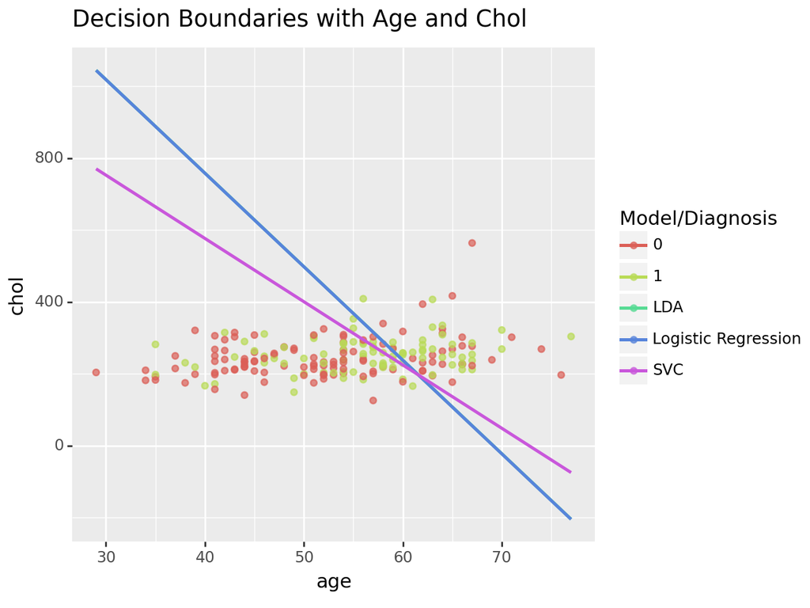

```python
# chatgpt assited with gathering my data into a plot.

scatter_data = data[['age', 'chol', 'diagnosis']]

x_values = np.linspace(data['age'].min(), data['age'].max(), 100)

def compute_boundary(pipeline, x_values):
    model = pipeline.named_steps[pipeline.steps[-1][0]]
    coef = model.coef_[0]
    intercept = model.intercept_
    return -(coef[0] / coef[1]) * x_values - (intercept / coef[1])

log_boundary = compute_boundary(logpredict, x_values)
lda_boundary = compute_boundary(ldapredict, x_values)
svc_boundary = compute_boundary(svecpredict, x_values)

log_df = pd.DataFrame({'age': x_values, 'chol': log_boundary, 'Model': 'Logistic Regression'})
lda_df = pd.DataFrame({'age': x_values, 'chol': lda_boundary, 'Model': 'LDA'})
svc_df = pd.DataFrame({'age': x_values, 'chol': svc_boundary, 'Model': 'SVC'})

boundaries = pd.concat([log_df, lda_df, svc_df])

plot = (ggplot(scatter_data, aes(x='age', y='chol', color='factor(diagnosis)')) +
        geom_point(alpha=0.7) +
        geom_line(boundaries, aes(x='age', y='chol', color='Model'), size=1) +
        ggtitle('Decision Boundaries with Age and Chol') +
        labs(color='Model/Diagnosis') +
        theme(legend_position='right'))

print(plot)
```